# Model Analysis

### Loading packages, defining colors and using data

```r
rm(list = ls())
library(reshape2)
library(base)
library(ggplot2)
library(grid)
library(scales)
library(stringr)
library(tidyverse)
library(formattable)

# should graphs be exported to pdf
export_pdf <- FALSE

# define some colors
mygreen <- "#00BA38"
myblue  <- "#619CFF"
myred   <- "#F8766D"
```

### Load parameters, log-linearization coefficients and empirical data

We now want to work with all our previous results. We therefore have to load all the data we previously stored in different files. This includes the model parameters in `chap07_parameters.RData`, the linearized coefficients in `chap07_coefficients.RData` and the empirical business cycle moments in `chap07_empirics.RData`.

```r
# get parameters stored in the RData set
load("chap07_parameters.RData")

# get coefficients stored in the RData set
load("chap07_coefficients.RData")

# get empirical data moments
load("chap07_empirics.RData")
```

### Impulse responses of a 1 percent productivity shock

To calculate the impulse response functions of the (linearized) real business cycle model to a 1 percent productivity shock, we have to take a couple of steps. First, we specify for how many quarters we want to simulate the impulse response in a variable `n_quarter`. Next we set up a matrix of shocks. Note that we measure all shocks and variables in percentage deviations from their steady state value. The matrix `shock` can contain shocks to all three state variables of the model. Setting `shock` to `matrix(c(0, 1, 0))` means that the capital stock and government consumption should remain at their steady state value but the productivity level should receive a positive 1 percent shock.

```r
# number of quarters
n_quarter <- 80

# initial shock at date t = 0 (in percent)
shock <- matrix(c(0, 1, 0))
```

```r
# initialize vectors x_t and y_t
x <- matrix(nrow=3, ncol=n_quarter+1)
y <- matrix(nrow=6, ncol=n_quarter+1)

# calculate x_1 and y_1
x[, 1] <- shock
y[, 1] <- B %*% x[, 1]

# iterate forward x_t and y_t
for(i in c(2:(n_quarter+1))) {
  x[, i] <- A %*% x[, i-1]
  y[, i] <- B %*% x[, i]
}

# generate dataframe from results
impulse <- data.frame(quarter=c(0:n_quarter), K=x[1, ], A=x[2, ], G=x[3, ], Y=y[1, ], C=y[2, ], I=y[3, ], r=y[4, ], w=y[5, ], L=y[6, ])
```

Once our data is simulated, we can plot it. We start with showing the dynamics of the capital stock, technology and labor supply (in percentage deviations from their steady state value).

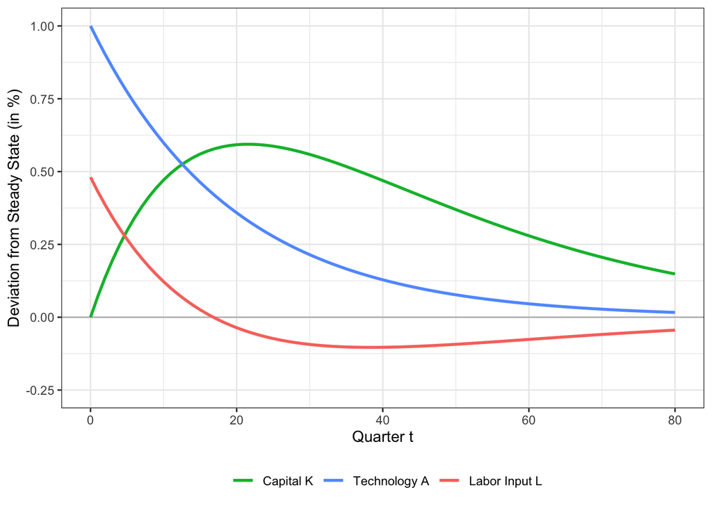

```r
# Plot impulse response of production sector
myplot <- ggplot(data = impulse) +
  geom_hline(yintercept=0, color="gray", linewidth=0.5) +
  geom_line(aes(x=quarter, y=K, color="capital"), linewidth=1) +
  geom_line(aes(x=quarter, y=A, color="tech"), linewidth=1) +
  geom_line(aes(x=quarter, y=L, color="labor"), linewidth=1) +
  labs(x = "Quarter t",
       y = "Deviation from Steady State (in %)") +
  scale_color_manual(breaks = c("capital", "tech", "labor"),
                     labels = c("Capital K", "Technology A", "Labor Input L"),
                     values = c(mygreen, myblue, myred), name='') +
  coord_cartesian(ylim=c(-0.25, 1)) +
  scale_y_continuous(breaks=seq(-0.25, 1, 0.25)) +
  theme_bw() +
  theme(legend.position="bottom")

# print the plot
print(myplot)
```

Next we plot consumption, investment and government expenditure, i.e. the components of GDP.

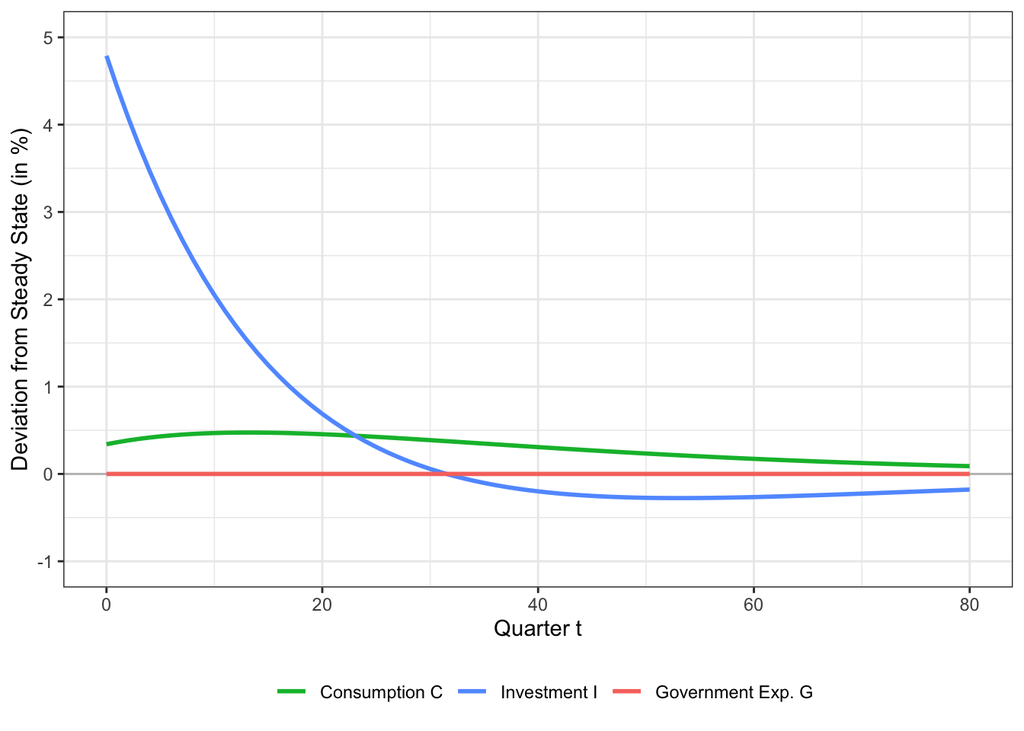

```r
# Plot impulse response of final goods
myplot <- ggplot(data = impulse) +
  geom_hline(yintercept=0, color="gray", linewidth=0.5) +
  geom_line(aes(x=quarter, y=C, color="cons"), linewidth=1) +
  geom_line(aes(x=quarter, y=I, color="inv"), linewidth=1) +
  geom_line(aes(x=quarter, y=G, color="gov"), linewidth=1) +
  labs(x = "Quarter t",
       y = "Deviation from Steady State (in %)") +
  scale_color_manual(breaks = c("cons", "inv", "gov"),
                     labels = c("Consumption C", "Investment I", "Government Exp. G"),
                     values = c(mygreen, myblue, myred), name='') +
  coord_cartesian(ylim=c(-1, 5)) +
  scale_y_continuous(breaks=seq(-1, 5, 1)) +
  theme_bw() +
  theme(legend.position="bottom")

# print the plot
print(myplot)
```

Finally, we show the factor prices for capital and labor.

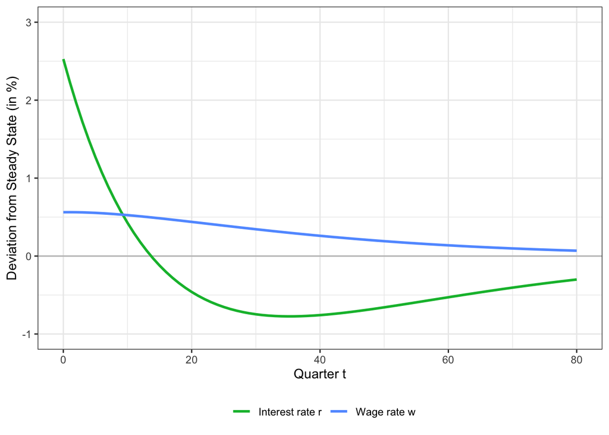

```r
# Plot impulse response of prices
myplot <- ggplot(data = impulse) +
  geom_hline(yintercept=0, color="gray", linewidth=0.5) +
  geom_line(aes(x=quarter, y=r, color="r"), linewidth=1) +
  geom_line(aes(x=quarter, y=w, color="w"), linewidth=1) +
  labs(x = "Quarter t",
       y = "Deviation from Steady State (in %)") +
  scale_color_manual(breaks = c("r", "w"),
                     labels = c("Interest rate r", "Wage rate w"),
                     values = c(mygreen, myblue, myred), name='') +
  coord_cartesian(ylim=c(-1, 3)) +
  scale_y_continuous(breaks=seq(-1, 3, 1)) +
  theme_bw() +
  theme(legend.position="bottom")

# print the plot
print(myplot)
```

### Impulse responses of a 1 percent government expenditure shock

Next, we calculate the impulse response to a one percent government expenditure shock. Mechanically, this works exactly in the same way as we simulated the technology shock. We just have to set `shock <- matrix(c(0, 0, 1))` to shock government expenditure and not technology.

```r
# number of quarters
n_quarter <- 80

# initial shock at date t = 0 (in percent)
shock <- matrix(c(0, 0, 1))

# initialize vectors x_t and y_t
x <- matrix(nrow=3, ncol=n_quarter+1)
y <- matrix(nrow=6, ncol=n_quarter+1)

# calculate x_1 and y_1
x[, 1] <- shock
y[, 1] <- B %*% x[, 1]

# iterate forward x_t and y_t
for(i in c(2:(n_quarter+1))) {
  x[, i] <- A %*% x[, i-1]
  y[, i] <- B %*% x[, i]
}

# generate dataframe from results
impulse <- data.frame(quarter=c(0:n_quarter), K=x[1, ], A=x[2, ], G=x[3, ], Y=y[1, ], C=y[2, ], I=y[3, ], r=y[4, ], w=y[5, ], L=y[6, ])
```

Again we can plot the dynamics of the capital stock, technology and labor.

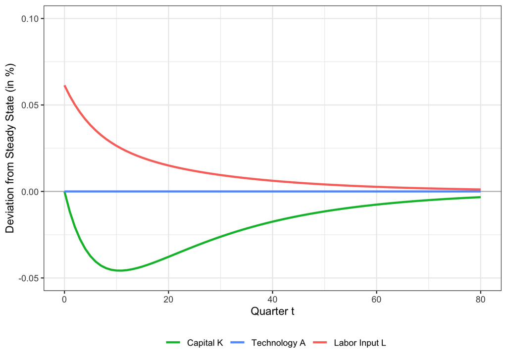

```r
# Plot impulse response of production sector
myplot <- ggplot(data = impulse) +
  geom_hline(yintercept=0, color="gray", linewidth=0.5) +
  geom_line(aes(x=quarter, y=K, color="capital"), linewidth=1) +
  geom_line(aes(x=quarter, y=A, color="tech"), linewidth=1) +
  geom_line(aes(x=quarter, y=L, color="labor"), linewidth=1) +
  labs(x = "Quarter t",
       y = "Deviation from Steady State (in %)") +
  scale_color_manual(breaks = c("capital", "tech", "labor"),
                     labels = c("Capital K", "Technology A", "Labor Input L"),
                     values = c(mygreen, myblue, myred), name='') +
  coord_cartesian(ylim=c(-0.05, 0.1)) +
  scale_y_continuous(breaks=seq(-0.05, 0.1, 0.05)) +
  theme_bw() +
  theme(legend.position="bottom")

# print the plot
print(myplot)
```

Next we plot consumption, investment and government expenditure, i.e. the components of GDP.

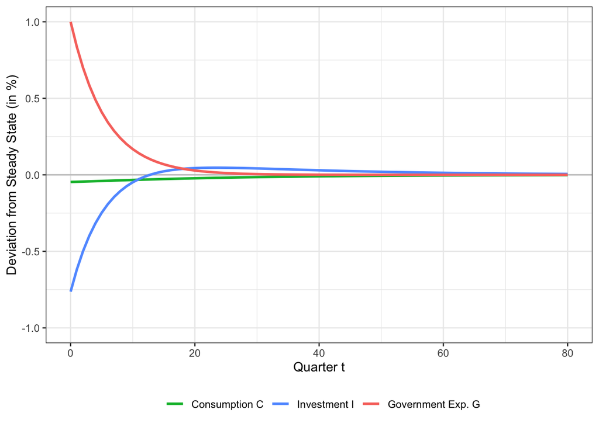

```r
# Plot impulse response of final goods
myplot <- ggplot(data = impulse) +
  geom_hline(yintercept=0, color="gray", linewidth=0.5) +
  geom_line(aes(x=quarter, y=C, color="cons"), linewidth=1) +
  geom_line(aes(x=quarter, y=I, color="inv"), linewidth=1) +
  geom_line(aes(x=quarter, y=G, color="gov"), linewidth=1) +
  labs(x = "Quarter t",
       y = "Deviation from Steady State (in %)") +
  scale_color_manual(breaks = c("cons", "inv", "gov"),
                     labels = c("Consumption C", "Investment I", "Government Exp. G"),
                     values = c(mygreen, myblue, myred), name='') +
  coord_cartesian(ylim=c(-1, 1)) +
  scale_y_continuous(breaks=seq(-1, 1, 0.5)) +
  theme_bw() +
  theme(legend.position="bottom")

# print the plot
print(myplot)
```

And finally, we show factor prices.

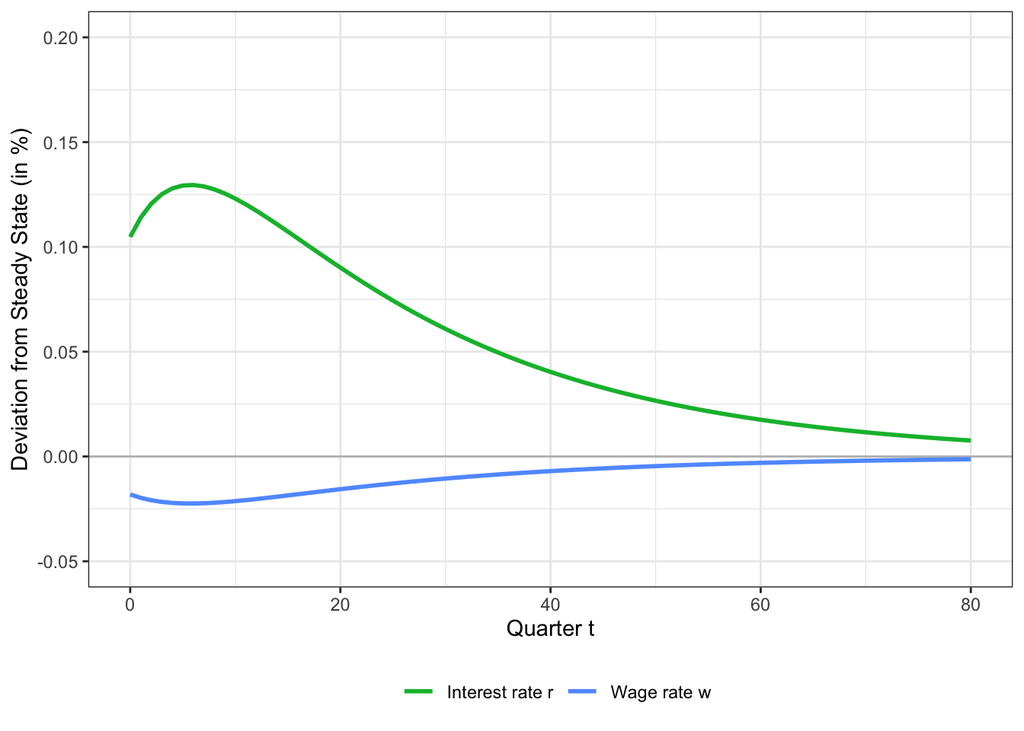

```r
# Plot impulse response of prices
myplot <- ggplot(data = impulse) +
  geom_hline(yintercept=0, color="gray", linewidth=0.5) +
  geom_line(aes(x=quarter, y=r, color="r"), linewidth=1) +
  geom_line(aes(x=quarter, y=w, color="w"), linewidth=1) +
  labs(x = "Quarter t",
       y = "Deviation from Steady State (in %)") +
  scale_color_manual(breaks = c("r", "w"),
                     labels = c("Interest rate r", "Wage rate w"),
                     values = c(mygreen, myblue, myred), name='') +
  coord_cartesian(ylim=c(-0.05, 0.2)) +
  scale_y_continuous(breaks=seq(-0.05, 0.2, 0.05)) +
  theme_bw() +
  theme(legend.position="bottom")

# print the plot
print(myplot)
```

### Hansen and Wright (1992) simulation methodology

Now we want to simulate our model to compare its second moments to the data. We use two different simulation methodologies. The first one is based on Hansen and Wright (1992). We first set the seed of the random number generate to some arbitrary variable. This allows us to simulate the same sequence of random numbers over and over again to insure comparability. Now we simulate 100 different times series from our model. Each time series will have 296 different quarters. We set the standard deviation of the technology shock to `sigma_A <- 0.00615`. This ensures that the standard deviation of GDP is equal to $1.89$, which it was in the data.

```r
# set the random seed to generate the same sequence of random variables
set.seed(351224332)

# number of simulations
n_sim <- 100

# number of quarters to simulate
n_quarter <- 296

# set standard deviation of a (calibration target is sd(Y))
sigma_A <- 0.00615
```

To use the Hansen and Wright (1992) methodology, we iterate over our `n_sim` different model simulations (variable `k`). For each simulation, we draw a new series of shocks for technology `a_shocks` and government expenditure `g_shocks`. We then apply the same simulation methodology as above to determine the time series of macroeconomic variables. Note that the only difference is the structure of shocks. For our impulse response functions, we assumed that there is only one shock in the initial period. Now, there will be shocks to technology and government expenditure in all periods.

Once the model data is simulated, we can calculate the standard deviations and correlations as we did in our empirical exercise. We then store the moments in an `array` named `hansen_data`. Note that we divide each moment by the value `n_sim`, because we take an average over the `n_sim` different model simulations.

```r
# initializes relevant statistics elements
hansen_data <- array(0, dim=c(6, 2))

# iterate over all simulated paths
for(k in c(1:n_sim)) {

  # draw a series of N(0,1) iid shocks
  a_shocks <- rnorm(n_quarter)
  g_shocks <- rnorm(n_quarter)

  # initialize vectors x_t and y_t
  x <- matrix(nrow=3, ncol=n_quarter)
  y <- matrix(nrow=6, ncol=n_quarter)

  # calculate x_1 and y_1
  x[, 1] <- matrix(c(0, sigma_A*a_shocks[1], sigma_G*g_shocks[1]))
  y[, 1] <- B %*% x[, 1]

  # iterate forward x_t and y_t
  for(i in c(2:(n_quarter))) {
    x[, i] <- A %*% x[, i-1] + matrix(c(0, sigma_A*a_shocks[i], sigma_G*g_shocks[i]))
    y[, i] <- B %*% x[, i]
  }

  # update data
  hansen_data[1, 1] <- hansen_data[1, 1] + sd(y[1, ])/n_sim
  hansen_data[2, 1] <- hansen_data[2, 1] + sd(y[2, ])/sd(y[1, ])/n_sim
  hansen_data[3, 1] <- hansen_data[3, 1] + sd(y[3, ])/sd(y[1, ])/n_sim
  hansen_data[4, 1] <- hansen_data[4, 1] + sd(y[5, ])/sd(y[1, ])/n_sim
  hansen_data[5, 1] <- hansen_data[5, 1] + sd(y[6, ])/sd(y[1, ])/n_sim
  hansen_data[6, 1] <- hansen_data[6, 1] + sd(y[6, ])/sd(y[5, ])/n_sim

  hansen_data[1, 2] <- 1
  hansen_data[2, 2] <- hansen_data[2, 2] + cor(y[2, ], y[1, ])/n_sim
  hansen_data[3, 2] <- hansen_data[3, 2] + cor(y[3, ], y[1, ])/n_sim
  hansen_data[4, 2] <- hansen_data[4, 2] + cor(y[5, ], y[1, ])/n_sim
  hansen_data[5, 2] <- hansen_data[5, 2] + cor(y[6, ], y[1, ])/n_sim
  hansen_data[6, 2] <- hansen_data[6, 2] + cor(y[6, ], y[5, ])/n_sim
}
```

### Simulation with (almost) irrelevant initial conditions

```r
# set the random seed to generate the same sequence of random variables
set.seed(351224332)

# number of quarters to simulate
n_quarter <- 100000

# set standard deviation of a (calibration target is sd(Y))
sigma_A <- 0.00553

# initializes relevant statistics elements
sim_data <- array(0, dim=c(6, 2))

# draw a series of N(0,1) iid shocks
a_shocks <- rnorm(n_quarter)
g_shocks <- rnorm(n_quarter)

# initialize vectors x_t and y_t
x <- matrix(nrow=3, ncol=n_quarter)
y <- matrix(nrow=6, ncol=n_quarter)

# calculate x_1 and y_1
x[, 1] <- matrix(c(0, sigma_A*a_shocks[1], sigma_G*g_shocks[1]))
y[, 1] <- B %*% x[, 1]

# iterate forward x_t and y_t
for(i in c(2:(n_quarter))) {
  x[, i] <- A %*% x[, i-1] + matrix(c(0, sigma_A*a_shocks[i], sigma_G*g_shocks[i]))
  y[, i] <- B %*% x[, i]
}

# update data
sim_data[1, 1] <- sd(y[1, ])
sim_data[2, 1] <- sd(y[2, ])/sd(y[1, ])
sim_data[3, 1] <- sd(y[3, ])/sd(y[1, ])
sim_data[4, 1] <- sd(y[5, ])/sd(y[1, ])
sim_data[5, 1] <- sd(y[6, ])/sd(y[1, ])
sim_data[6, 1] <- sd(y[6, ])/sd(y[5, ])

sim_data[1, 2] <- 1
sim_data[2, 2] <- cor(y[2, ], y[1, ])
sim_data[3, 2] <- cor(y[3, ], y[1, ])
sim_data[4, 2] <- cor(y[5, ], y[1, ])
sim_data[5, 2] <- cor(y[6, ], y[1, ])
sim_data[6, 2] <- cor(y[6, ], y[5, ])
```

### Comparison of model simulations with the data

Lastly, we compare the moments generated from our model simulations to the moments we calculated from FRED with real US data. We put these numbers into a table. We can see that the business cycle model is successful in matching some dimensions of the data, but it fails on others. In addition, the simulation methodology has some impact on the results. However, the results are at least qualitatively the same, regardless of the methodology used.

```r
# generate data table
table_data <- data.frame("Statistics" =
                           c("sd(Y) in %",
                             "sd(C)/sd(Y)", "corr(C, Y)",
                             "sd(I)/sd(Y)", "corr(I, Y)",
                             "sd(w)/sd(Y)", "corr(w, Y)",
                             "sd(L)/sd(Y)", "corr(L, Y)",
                             "sd(L)/sd(w)", "corr(L, w)"))
table_data <- cbind(table_data, "Empirical Moments" =
                      c(emp_data[1, 1]*100, emp_data[2, 1], emp_data[2, 2], emp_data[3, 1],
                        emp_data[3, 2], emp_data[4, 1], emp_data[4, 2], emp_data[5, 1],
                        emp_data[5, 2], emp_data[6, 1], emp_data[6, 2]))
table_data <- cbind(table_data, "Hansen and Wright (1992)" =
                      c(hansen_data[1, 1]*100, hansen_data[2, 1], hansen_data[2, 2], hansen_data[3, 1],
                        hansen_data[3, 2], hansen_data[4, 1], hansen_data[4, 2], hansen_data[5, 1],
                        hansen_data[5, 2], hansen_data[6, 1], hansen_data[6, 2]))
table_data <- cbind(table_data, "No Initial Conditions" =
                      c(sim_data[1, 1]*100, sim_data[2, 1], sim_data[2, 2], sim_data[3, 1],
                        sim_data[3, 2], sim_data[4, 1], sim_data[4, 2], sim_data[5, 1],
                        sim_data[5, 2], sim_data[6, 1], sim_data[6, 2]))

# output table
formattable(table_data, digits = 2,
            align= c("l", "r", "r", "r"))
```

| Statistics | Empirical Moments | Hansen and Wright (1992) | No Initial Conditions |
| --- | --- | --- | --- |
| sd(Y) in % | 1.89 | 1.89 | 1.89 |
| sd(C)/sd(Y) | 0.56 | 0.76 | 0.85 |
| corr(C, Y) | 0.71 | 0.84 | 0.86 |
| sd(I)/sd(Y) | 2.47 | 3.78 | 3.54 |
| corr(I, Y) | 0.86 | 0.91 | 0.88 |
| sd(w)/sd(Y) | 0.60 | 0.81 | 0.87 |
| corr(w, Y) | 0.29 | 0.94 | 0.94 |
| sd(L)/sd(Y) | 1.11 | 0.37 | 0.35 |
| corr(L, Y) | 0.84 | 0.64 | 0.52 |
| sd(L)/sd(w) | 1.86 | 0.47 | 0.41 |
| corr(L, w) | -0.22 | 0.34 | 0.19 |